# SI618 Lab 9

In this lab, we will be working with three different datasets

1. The UCI data set about wine quality from lab 8. The dataset comes from https://www.kaggle.com/uciml/red-wine-quality-cortez-et-al-2009
2. Selected gender inequality related data from global development database downloaded from the World Bank data bank (https://databank.worldbank.org/reports.aspx?source=world-development-indicators#). Read the metadata file for more information about the two variables being used.
3. A monthly time series dataset of the number of domestic airline passengers (in 000s) in the United States collected from https://www.transtats.bts.gov/TRAFFIC/

## Part 1: Wine Quality

### Question 1: (15 points) Load the wine quality dataset. Define a new column **isgood** based on the **quality** column with wines with a quality rating higher than 5 being *good* and the rest being *bad*.

- Use a JointGrid approach look at the relationship between sulphates and alcohol.
- Look at the same relationship separately for *good* and *bad* wines with separate JointGrids
- What do you observe?

Hint: When appropriate, create additional figures that allow you to exclude the effect of outliers

```python
import pandas as pd
import seaborn as sns
import numpy as np
import matplotlib.pyplot as plt
%matplotlib inline
```

```python
wine = pd.read_csv('winequality-red.csv')
wine.head()
```

|  | fixed acidity | volatile acidity | citric acid | residual sugar | chlorides | free sulfur dioxide | total sulfur dioxide | density | pH | sulphates | alcohol | quality |
| --- | --- | --- | --- | --- | --- | --- | --- | --- | --- | --- | --- | --- |
| 0 | 7.4 | 0.70 | 0.00 | 1.9 | 0.076 | 11.0 | 34.0 | 0.9978 | 3.51 | 0.56 | 9.4 | 5 |
| 1 | 7.8 | 0.88 | 0.00 | 2.6 | 0.098 | 25.0 | 67.0 | 0.9968 | 3.20 | 0.68 | 9.8 | 5 |
| 2 | 7.8 | 0.76 | 0.04 | 2.3 | 0.092 | 15.0 | 54.0 | 0.9970 | 3.26 | 0.65 | 9.8 | 5 |
| 3 | 11.2 | 0.28 | 0.56 | 1.9 | 0.075 | 17.0 | 60.0 | 0.9980 | 3.16 | 0.58 | 9.8 | 6 |
| 4 | 7.4 | 0.70 | 0.00 | 1.9 | 0.076 | 11.0 | 34.0 | 0.9978 | 3.51 | 0.56 | 9.4 | 5 |

```python
wine['isgood'] = np.where(wine['quality'] > 5, 'good','bad')
wine
```

|  | fixed acidity | volatile acidity | citric acid | residual sugar | chlorides | free sulfur dioxide | total sulfur dioxide | density | pH | sulphates | alcohol | quality | isgood |
| --- | --- | --- | --- | --- | --- | --- | --- | --- | --- | --- | --- | --- | --- |
| 0 | 7.4 | 0.700 | 0.00 | 1.9 | 0.076 | 11.0 | 34.0 | 0.99780 | 3.51 | 0.56 | 9.4 | 5 | bad |
| 1 | 7.8 | 0.880 | 0.00 | 2.6 | 0.098 | 25.0 | 67.0 | 0.99680 | 3.20 | 0.68 | 9.8 | 5 | bad |
| 2 | 7.8 | 0.760 | 0.04 | 2.3 | 0.092 | 15.0 | 54.0 | 0.99700 | 3.26 | 0.65 | 9.8 | 5 | bad |
| 3 | 11.2 | 0.280 | 0.56 | 1.9 | 0.075 | 17.0 | 60.0 | 0.99800 | 3.16 | 0.58 | 9.8 | 6 | good |
| 4 | 7.4 | 0.700 | 0.00 | 1.9 | 0.076 | 11.0 | 34.0 | 0.99780 | 3.51 | 0.56 | 9.4 | 5 | bad |
| ... | ... | ... | ... | ... | ... | ... | ... | ... | ... | ... | ... | ... | ... |
| 1594 | 6.2 | 0.600 | 0.08 | 2.0 | 0.090 | 32.0 | 44.0 | 0.99490 | 3.45 | 0.58 | 10.5 | 5 | bad |
| 1595 | 5.9 | 0.550 | 0.10 | 2.2 | 0.062 | 39.0 | 51.0 | 0.99512 | 3.52 | 0.76 | 11.2 | 6 | good |
| 1596 | 6.3 | 0.510 | 0.13 | 2.3 | 0.076 | 29.0 | 40.0 | 0.99574 | 3.42 | 0.75 | 11.0 | 6 | good |
| 1597 | 5.9 | 0.645 | 0.12 | 2.0 | 0.075 | 32.0 | 44.0 | 0.99547 | 3.57 | 0.71 | 10.2 | 5 | bad |
| 1598 | 6.0 | 0.310 | 0.47 | 3.6 | 0.067 | 18.0 | 42.0 | 0.99549 | 3.39 | 0.66 | 11.0 | 6 | good |

1599 rows × 13 columns

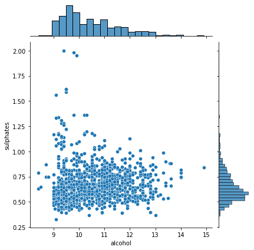

```python
g = sns.JointGrid(data=wine, x="alcohol", y="sulphates")
g.plot(sns.scatterplot, sns.histplot)
```

There is no obvious relationship between the two variables. As one variable rises, the distribution of the other variable does not see a particularly significant change.

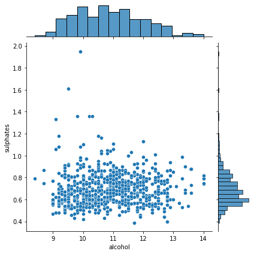

```python
good_wine = wine[wine['isgood']=='good']
g = sns.JointGrid(data=good_wine, x="alcohol", y="sulphates")
g.plot(sns.scatterplot, sns.histplot)
```

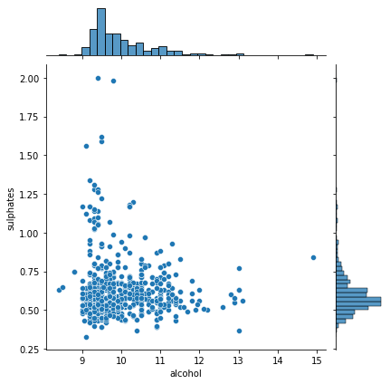

```python
bad_wine = wine[wine['isgood']=='bad']
g = sns.JointGrid(data=bad_wine, x="alcohol", y="sulphates")
g.plot(sns.scatterplot, sns.histplot)
```

### Question 2: (15 points) Use OLS to perform either a regression or an ANOVA for the relationship between sulphates with (i) categorical variable of wine quality and (ii) original quality. Interpret your results.

```python
import statsmodels.api as sm
import statsmodels.formula.api as smf
```

```python
model = smf.ols('sulphates ~ C(isgood)', data=wine).fit()
model.summary()
```

OLS Regression Results

| Dep. Variable: | sulphates | R-squared: | 0.048 |
| --- | --- | --- | --- |
| Model: | OLS | Adj. R-squared: | 0.047 |
| Method: | Least Squares | F-statistic: | 79.74 |
| Date: | Wed, 17 Nov 2021 | Prob (F-statistic): | 1.15e-18 |
| Time: | 12:39:34 | Log-Likelihood: | 608.57 |
| No. Observations: | 1599 | AIC: | -1213. |
| Df Residuals: | 1597 | BIC: | -1202. |
| Df Model: | 1 |  |  |
| Covariance Type: | nonrobust |  |  |

|  | coef | std err | t | P>\|t\| | [0.025 | 0.975] |
| --- | --- | --- | --- | --- | --- | --- |
| Intercept | 0.6185 | 0.006 | 101.955 | 0.000 | 0.607 | 0.630 |
| C(isgood)[T.good] | 0.0741 | 0.008 | 8.930 | 0.000 | 0.058 | 0.090 |

| Omnibus: | 1001.323 | Durbin-Watson: | 1.595 |
| --- | --- | --- | --- |
| Prob(Omnibus): | 0.000 | Jarque-Bera (JB): | 14483.316 |
| Skew: | 2.695 | Prob(JB): | 0.00 |
| Kurtosis: | 16.723 | Cond. No. | 2.71 |

Notes:  
[1] Standard Errors assume that the covariance matrix of the errors is correctly specified.

```python
aov_table = sm.stats.anova_lm(model, typ=2)
print(aov_table)
```

```
              sum_sq      df         F        PR(>F)
C(isgood)   2.183486     1.0  79.73768  1.147929e-18
Residual   43.731235  1597.0       NaN           NaN
```

```python
model = smf.ols('sulphates ~ quality', data=wine).fit()
model.summary()
```

OLS Regression Results

| Dep. Variable: | sulphates | R-squared: | 0.063 |
| --- | --- | --- | --- |
| Model: | OLS | Adj. R-squared: | 0.063 |
| Method: | Least Squares | F-statistic: | 107.7 |
| Date: | Wed, 17 Nov 2021 | Prob (F-statistic): | 1.80e-24 |
| Time: | 12:39:34 | Log-Likelihood: | 621.82 |
| No. Observations: | 1599 | AIC: | -1240. |
| Df Residuals: | 1597 | BIC: | -1229. |
| Df Model: | 1 |  |  |
| Covariance Type: | nonrobust |  |  |

|  | coef | std err | t | P>\|t\| | [0.025 | 0.975] |
| --- | --- | --- | --- | --- | --- | --- |
| Intercept | 0.3607 | 0.029 | 12.464 | 0.000 | 0.304 | 0.418 |
| quality | 0.0528 | 0.005 | 10.380 | 0.000 | 0.043 | 0.063 |

| Omnibus: | 1042.311 | Durbin-Watson: | 1.598 |
| --- | --- | --- | --- |
| Prob(Omnibus): | 0.000 | Jarque-Bera (JB): | 16731.569 |
| Skew: | 2.811 | Prob(JB): | 0.00 |
| Kurtosis: | 17.816 | Cond. No. | 41.4 |

Notes:  
[1] Standard Errors assume that the covariance matrix of the errors is correctly specified.

```python
aov_table = sm.stats.anova_lm(model, typ=2)
print(aov_table)
```

```
             sum_sq      df           F        PR(>F)
quality    2.901833     1.0  107.740433  1.802088e-24
Residual  43.012888  1597.0         NaN           NaN
```

## Part 2: Trends in Gender Inequality

### Question 3: (15 points) Visualize the relationship between the representation of women in the parliment (**SG.GEN.PARL.ZS**) and the legal and regulatory support for providing economic opportunities for women (**SG.LAW.INDX**) in the year 2020 using a scatter plot drawn with plotnine (*geom_point*). Then overlay a linear regression fit with the standard error confidence intervals on the same plot (*geom smooth*). Remember to label and resize the figure as necessary to make it readable. What do you observe?

```python
from plotnine import ggplot, geom_point, aes, geom_line, ggtitle, geom_smooth, xlab, ylab, xlim, ylim
```

```python
gender = pd.read_csv('gender_world_development.csv')
gender.head()
```

|  | Unnamed: 0 | Country Name | Country Code | Series Name | Series Code | 1960 [YR1960] | 1961 [YR1961] | 1962 [YR1962] | 1963 [YR1963] | 1964 [YR1964] | ... | 2011 [YR2011] | 2012 [YR2012] | 2013 [YR2013] | 2014 [YR2014] | 2015 [YR2015] | 2016 [YR2016] | 2017 [YR2017] | 2018 [YR2018] | 2019 [YR2019] | 2020 [YR2020] |
| --- | --- | --- | --- | --- | --- | --- | --- | --- | --- | --- | --- | --- | --- | --- | --- | --- | --- | --- | --- | --- | --- |
| 0 | 0 | Afghanistan | AFG | Proportion of seats held by women in national ... | SG.GEN.PARL.ZS | NaN | NaN | NaN | NaN | NaN | ... | 27.710843 | 27.710843 | 27.710843 | 27.710843 | 27.710843 | 27.710843 | 27.710843 | NaN | 27.868852 | 27.016129 |
| 1 | 4 | Afghanistan | AFG | Women Business and the Law Index Score (scale ... | SG.LAW.INDX | NaN | NaN | NaN | NaN | NaN | ... | 28.750000 | 28.750000 | 28.750000 | 28.750000 | 28.750000 | 38.125000 | 38.125000 | 38.125000 | 38.125000 | 38.125000 |
| 2 | 13 | Albania | ALB | Proportion of seats held by women in national ... | SG.GEN.PARL.ZS | NaN | NaN | NaN | NaN | NaN | ... | 15.714286 | 15.714286 | 17.857143 | 20.000000 | 20.714286 | 22.857143 | 27.857143 | 27.857143 | 29.508197 | 29.508197 |
| 3 | 17 | Albania | ALB | Women Business and the Law Index Score (scale ... | SG.LAW.INDX | NaN | NaN | NaN | NaN | NaN | ... | 85.625000 | 85.625000 | 85.625000 | 85.625000 | 85.625000 | 91.250000 | 91.250000 | 91.250000 | 91.250000 | 91.250000 |
| 4 | 26 | Algeria | DZA | Proportion of seats held by women in national ... | SG.GEN.PARL.ZS | NaN | NaN | NaN | NaN | NaN | ... | 7.969152 | 31.601732 | 31.601732 | 31.601732 | 31.601732 | 31.601732 | 25.757576 | 25.757576 | 25.757576 | 25.757576 |

5 rows × 66 columns

```python
parl = gender[gender['Series Code'] == 'SG.GEN.PARL.ZS']
law = gender[gender['Series Code'] == 'SG.LAW.INDX']
```

```python
merged = parl.merge(law, on="Country Name")
merged.head()
```

|  | Unnamed: 0_x | Country Name | Country Code_x | Series Name_x | Series Code_x | 1960 [YR1960]_x | 1961 [YR1961]_x | 1962 [YR1962]_x | 1963 [YR1963]_x | 1964 [YR1964]_x | ... | 2011 [YR2011]_y | 2012 [YR2012]_y | 2013 [YR2013]_y | 2014 [YR2014]_y | 2015 [YR2015]_y | 2016 [YR2016]_y | 2017 [YR2017]_y | 2018 [YR2018]_y | 2019 [YR2019]_y | 2020 [YR2020]_y |
| --- | --- | --- | --- | --- | --- | --- | --- | --- | --- | --- | --- | --- | --- | --- | --- | --- | --- | --- | --- | --- | --- |
| 0 | 0 | Afghanistan | AFG | Proportion of seats held by women in national ... | SG.GEN.PARL.ZS | NaN | NaN | NaN | NaN | NaN | ... | 28.750 | 28.750 | 28.750 | 28.750 | 28.750 | 38.125 | 38.125 | 38.125 | 38.125 | 38.125 |
| 1 | 13 | Albania | ALB | Proportion of seats held by women in national ... | SG.GEN.PARL.ZS | NaN | NaN | NaN | NaN | NaN | ... | 85.625 | 85.625 | 85.625 | 85.625 | 85.625 | 91.250 | 91.250 | 91.250 | 91.250 | 91.250 |
| 2 | 26 | Algeria | DZA | Proportion of seats held by women in national ... | SG.GEN.PARL.ZS | NaN | NaN | NaN | NaN | NaN | ... | 55.000 | 55.000 | 55.000 | 55.000 | 55.000 | 57.500 | 57.500 | 57.500 | 57.500 | 57.500 |
| 3 | 39 | American Samoa | ASM | Proportion of seats held by women in national ... | SG.GEN.PARL.ZS | NaN | NaN | NaN | NaN | NaN | ... | NaN | NaN | NaN | NaN | NaN | NaN | NaN | NaN | NaN | NaN |
| 4 | 52 | Andorra | AND | Proportion of seats held by women in national ... | SG.GEN.PARL.ZS | NaN | NaN | NaN | NaN | NaN | ... | NaN | NaN | NaN | NaN | NaN | NaN | NaN | NaN | NaN | NaN |

5 rows × 131 columns

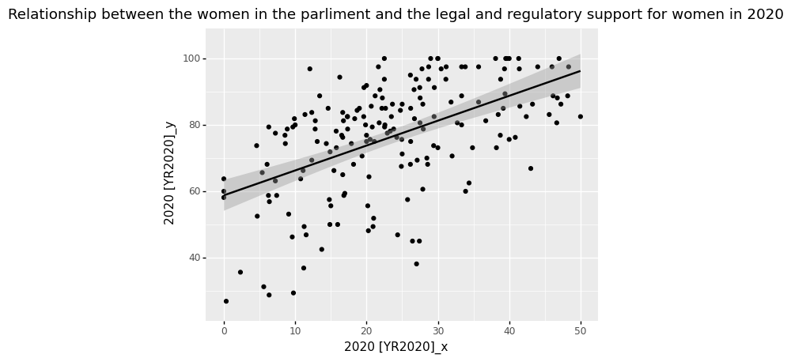

```python
ggplot(merged, aes(x='2020 [YR2020]_x', y='2020 [YR2020]_y')) + geom_point() + geom_smooth(method='lm', se=True) + ggtitle("Relationship between the women in the parliment and the legal and regulatory support for women in 2020") + xlim(0, 50) + ylim(25, 105)
```

### Question 4: (10 points) Visualize the evolution of the proportion of women in the legislature in the United States over the years using a line plot

Hint: You can use the pandas *melt* function to convert columns to rows

```python
us = gender[(gender['Country Name'] == 'United States') & (gender['Series Code'] == 'SG.GEN.PARL.ZS')]
us
```

|  | Unnamed: 0 | Country Name | Country Code | Series Name | Series Code | 1960 [YR1960] | 1961 [YR1961] | 1962 [YR1962] | 1963 [YR1963] | 1964 [YR1964] | ... | 2011 [YR2011] | 2012 [YR2012] | 2013 [YR2013] | 2014 [YR2014] | 2015 [YR2015] | 2016 [YR2016] | 2017 [YR2017] | 2018 [YR2018] | 2019 [YR2019] | 2020 [YR2020] |
| --- | --- | --- | --- | --- | --- | --- | --- | --- | --- | --- | --- | --- | --- | --- | --- | --- | --- | --- | --- | --- | --- |
| 412 | 2678 | United States | USA | Proportion of seats held by women in national ... | SG.GEN.PARL.ZS | NaN | NaN | NaN | NaN | NaN | ... | 16.820276 | 17.97235 | 17.824074 | 19.310345 | 19.354839 | 19.168591 | 19.354839 | 23.502304 | 23.433875 | 27.464789 |

1 rows × 66 columns

```python
evol = pd.melt(us, id_vars=['Unnamed: 0', 'Country Name', 'Country Code', 'Series Name', 'Series Code'])
evol['year'] = [int(year.split()[0]) for year in evol['variable']]
evol = evol.dropna()
evol.head()
```

|  | Unnamed: 0 | Country Name | Country Code | Series Name | Series Code | variable | value | year |
| --- | --- | --- | --- | --- | --- | --- | --- | --- |
| 37 | 2678 | United States | USA | Proportion of seats held by women in national ... | SG.GEN.PARL.ZS | 1997 [YR1997] | 11.724138 | 1997 |
| 38 | 2678 | United States | USA | Proportion of seats held by women in national ... | SG.GEN.PARL.ZS | 1998 [YR1998] | 11.724138 | 1998 |
| 39 | 2678 | United States | USA | Proportion of seats held by women in national ... | SG.GEN.PARL.ZS | 1999 [YR1999] | 13.333333 | 1999 |
| 41 | 2678 | United States | USA | Proportion of seats held by women in national ... | SG.GEN.PARL.ZS | 2001 [YR2001] | 14.022989 | 2001 |
| 42 | 2678 | United States | USA | Proportion of seats held by women in national ... | SG.GEN.PARL.ZS | 2002 [YR2002] | 13.793103 | 2002 |

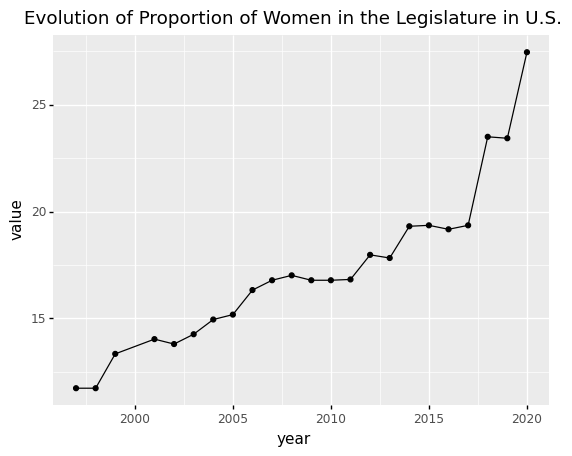

```python
ggplot(evol, aes('year', 'value')) + geom_line(aes(group = 1)) + geom_point() + ggtitle("Evolution of Proportion of Women in the Legislature in U.S.")
```

We can see a very clear upward trend in the proportion of women in the legislature in the United States over the years.

### Question 5: (20 points) Create the visualization from Q4 for the 10 most populus countries in the world (China, India, US, Indonesia, Pakistan, Brazil, Nigeria, Bangladesh, Russia, Mexico) using a facet grid from plotnine. Remember to format the figure for reability. What are your observations?

```python
from plotnine import facet_grid, labs, theme
```

```python
populus = gender[(gender['Country Name'].isin(['China', 'India', 'United States', 'Indonesia', 'Pakistan', 'Brazil', 'Nigeria', 'Bangladesh', 'Russia', 'Mexico']))  & (gender['Series Code'] == 'SG.GEN.PARL.ZS')]
populus.head()
```

|  | Unnamed: 0 | Country Name | Country Code | Series Name | Series Code | 1960 [YR1960] | 1961 [YR1961] | 1962 [YR1962] | 1963 [YR1963] | 1964 [YR1964] | ... | 2011 [YR2011] | 2012 [YR2012] | 2013 [YR2013] | 2014 [YR2014] | 2015 [YR2015] | 2016 [YR2016] | 2017 [YR2017] | 2018 [YR2018] | 2019 [YR2019] | 2020 [YR2020] |
| --- | --- | --- | --- | --- | --- | --- | --- | --- | --- | --- | --- | --- | --- | --- | --- | --- | --- | --- | --- | --- | --- |
| 30 | 195 | Bangladesh | BGD | Proportion of seats held by women in national ... | SG.GEN.PARL.ZS | NaN | NaN | NaN | NaN | NaN | ... | 19.714286 | 19.714286 | 19.714286 | 19.827586 | 20.000000 | 20.000000 | 20.285714 | 20.285714 | 20.630372 | 20.916905 |
| 52 | 338 | Brazil | BRA | Proportion of seats held by women in national ... | SG.GEN.PARL.ZS | NaN | NaN | NaN | NaN | NaN | ... | 8.576998 | 8.576998 | 8.576998 | 9.941520 | 9.941520 | 9.941520 | 10.721248 | 15.009747 | 15.009747 | 14.619883 |
| 82 | 533 | China | CHN | Proportion of seats held by women in national ... | SG.GEN.PARL.ZS | NaN | NaN | NaN | NaN | NaN | ... | 21.323036 | 21.323036 | 23.401406 | 23.401406 | 23.622846 | 23.622846 | 24.247606 | 24.899329 | 24.941176 | 24.941176 |
| 178 | 1157 | India | IND | Proportion of seats held by women in national ... | SG.GEN.PARL.ZS | NaN | NaN | NaN | NaN | NaN | ... | 11.009174 | 11.009174 | 11.009174 | 11.418048 | 11.970534 | 11.970534 | 11.808118 | 11.808118 | 14.391144 | 14.364641 |
| 180 | 1170 | Indonesia | IDN | Proportion of seats held by women in national ... | SG.GEN.PARL.ZS | NaN | NaN | NaN | NaN | NaN | ... | 18.214286 | 18.571429 | 18.571429 | 16.936937 | 17.117117 | 17.117117 | 19.821429 | 19.821429 | 17.391304 | 20.347826 |

5 rows × 66 columns

```python
evol = pd.melt(populus, id_vars=['Unnamed: 0', 'Country Name', 'Country Code', 'Series Name', 'Series Code'])
evol['year'] = [int(year.split()[0]) for year in evol['variable']]
evol = evol.dropna()
evol.head()
```

|  | Unnamed: 0 | Country Name | Country Code | Series Name | Series Code | variable | value | year |
| --- | --- | --- | --- | --- | --- | --- | --- | --- |
| 333 | 195 | Bangladesh | BGD | Proportion of seats held by women in national ... | SG.GEN.PARL.ZS | 1997 [YR1997] | 9.090909 | 1997 |
| 334 | 338 | Brazil | BRA | Proportion of seats held by women in national ... | SG.GEN.PARL.ZS | 1997 [YR1997] | 6.627680 | 1997 |
| 336 | 1157 | India | IND | Proportion of seats held by women in national ... | SG.GEN.PARL.ZS | 1997 [YR1997] | 7.155963 | 1997 |
| 337 | 1170 | Indonesia | IDN | Proportion of seats held by women in national ... | SG.GEN.PARL.ZS | 1997 [YR1997] | 11.400000 | 1997 |
| 338 | 1651 | Mexico | MEX | Proportion of seats held by women in national ... | SG.GEN.PARL.ZS | 1997 [YR1997] | 14.200000 | 1997 |

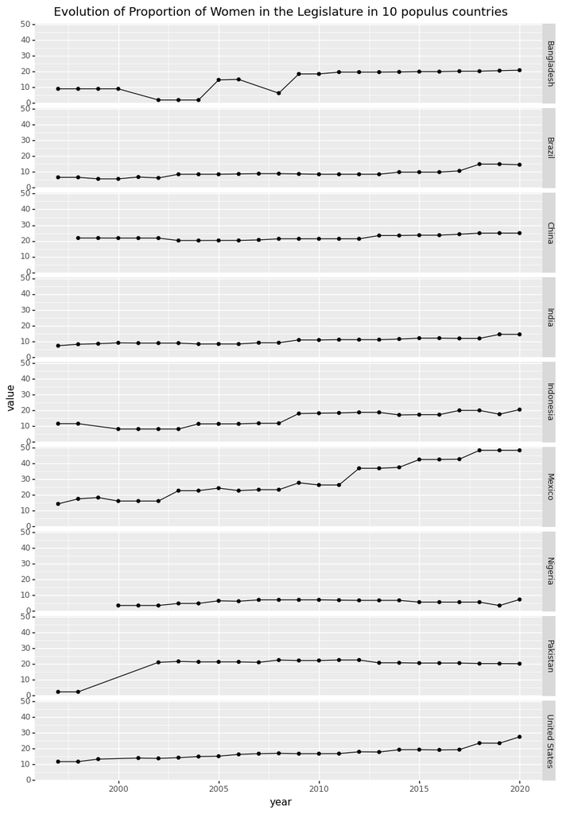

```python
ggplot(evol, aes(x='year', y='value')) + geom_point() + geom_line() + ggtitle("Evolution of Proportion of Women in the Legislature in 10 populus countries") + facet_grid('Country Name ~ .') + theme(figure_size=(10, 15))
```

## Part 3: Domestic Air Travel in the United States

### Question 6: (10 points) Load the airline passenger dataset. Using plotnine, visualize the monthly time series of the number of domestic passengers with overlayed point and line plots. Format and label the plot to be readable.

Hint: You can use the mizani package to generate the axis breaks and formatted labels

```python
from plotnine import geom_smooth, stat_summary, scale_x_datetime
from mizani.breaks import date_breaks
from mizani.formatters import date_format
from datetime import date
```

```python
airline = pd.read_csv('us_domestic_airline_passengers.csv')
airline.head()
```

|  | Period | Passengers |
| --- | --- | --- |
| 0 | January 2002 | 38499 |
| 1 | February 2002 | 38561 |
| 2 | March 2002 | 48397 |
| 3 | April 2002 | 45358 |
| 4 | May 2002 | 47050 |

```python
airline['Period'] = pd.to_datetime(airline['Period'])
airline.head()
```

|  | Period | Passengers |
| --- | --- | --- |
| 0 | 2002-01-01 | 38499 |
| 1 | 2002-02-01 | 38561 |
| 2 | 2002-03-01 | 48397 |
| 3 | 2002-04-01 | 45358 |
| 4 | 2002-05-01 | 47050 |

```python
airline['month'] = airline['Period'].dt.month
airline['year'] = airline['Period'].dt.year
airline.head()
```

|  | Period | Passengers | month | year |
| --- | --- | --- | --- | --- |
| 0 | 2002-01-01 | 38499 | 1 | 2002 |
| 1 | 2002-02-01 | 38561 | 2 | 2002 |
| 2 | 2002-03-01 | 48397 | 3 | 2002 |
| 3 | 2002-04-01 | 45358 | 4 | 2002 |
| 4 | 2002-05-01 | 47050 | 5 | 2002 |

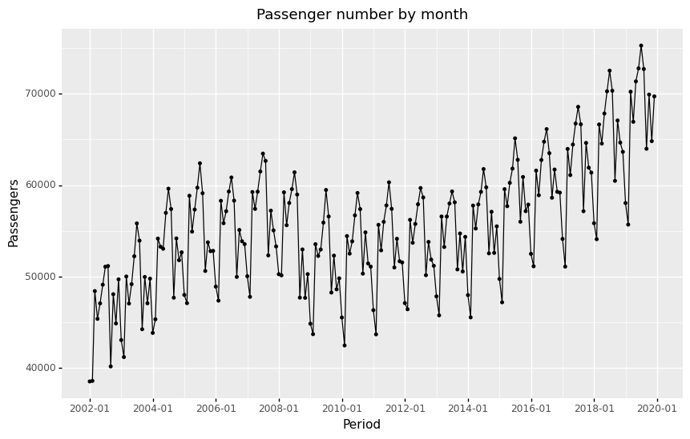

```python
ggplot(airline, aes('Period', 'Passengers')) + geom_line() + geom_point(size=1) + ggtitle("Passenger number by month") + scale_x_datetime(breaks=date_breaks('2 years'), labels=date_format('%Y-%m')) + theme(figure_size=(10, 6))
```

The number of passengers fluctuates up and down with the month. But overall there is an upward trend.

### Question 7: (15 points) Remove the monthly seasonal effect from the passenger time series and plot the adjusted passenger (mean + residual) time series. What do you observe?

```python
model = smf.ols('Passengers ~ C(month)', data=airline).fit()
airline['Passengers_ds'] = model.resid
```

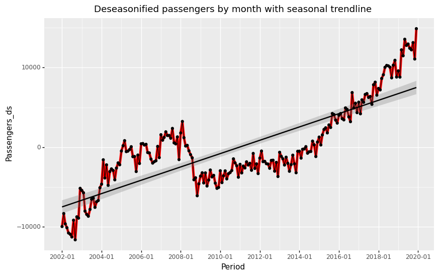

```python
avg = stat_summary(aes(group = 1), fun_y = np.mean, geom = "line", colour = "red", size = 2, na_rm = True)

line = geom_smooth(aes(group = 1),method='lm')
ggplot(airline, aes('Period', 'Passengers_ds')) + avg + line + \
  ggtitle("Deseasonified passengers by month with seasonal trendline") + \
  geom_line() + geom_point() + scale_x_datetime(breaks=date_breaks('2 years'), labels=date_format('%Y-%m')) + theme(figure_size=(10, 6))
```

We can see more clearly that the number of passengers tends to increase with the month. What is more noteworthy is that there was a sharp drop starting from about 2008-03.

## What to submit

- The jupyter notebook file named 'uniquename_si618*lab9*.ipynb'
- The HTML or PDF report generated by your notebook file that should similar to si618_lab9_solution.html